# Eurovision Song Contest country profile

2025-05-02

# Andorra

## Participation and successes

Andorra has participated in the Eurovision Song Contest 6 times. It made it to the final round 0 times - that’s 0%.

Andorra has won 0 times. Its most successful performance took place in the 2007 semi-final, when the country got 3.3% of all possible points.

## Final place distribution

Here’s how many times Andorra earned a particular place in the final round of Eurovision:

```
## This country has not participated in the final round.
```

## Loyal besties

Below are the countries that have NEVER given Andorra zero points. The bar chart shows the lowest score those countries gave Andorra instead.

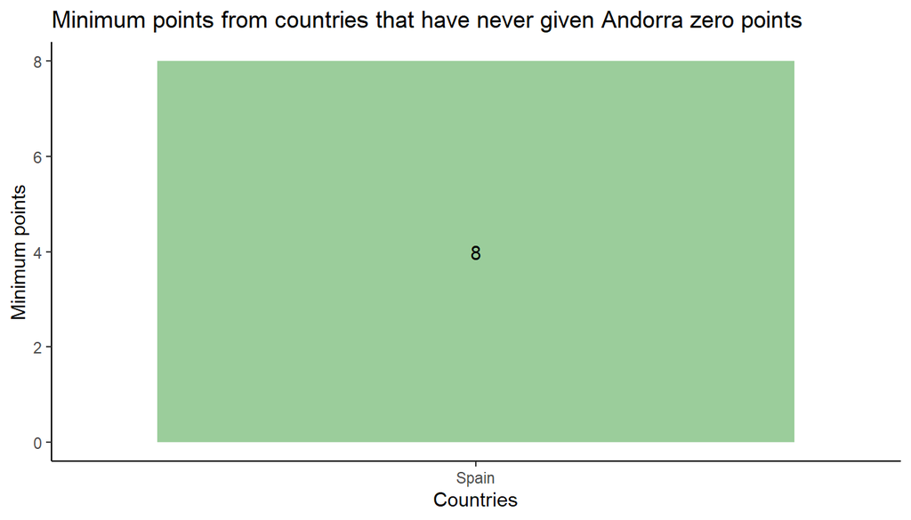

## Only zeros

On the other hand, here are the countries that have never given Andorra more than zero points.

```
## countries that have never given  Andorra  more than zero points:
##
## - Armenia
## - Austria
## - Azerbaijan
## - Belgium
## - Bosnia and Herzegovina
## - Bulgaria
## - Cyprus
## - Denmark
## - France
## - Georgia
## - Germany
## - Hungary
## - Latvia
## - Monaco
## - Montenegro
## - Romania
## - San Marino
## - Serbia
## - Serbia and Montenegro
## - Switzerland
## - Ukraine
## - United Kingdom
```

## Birds of a feather sing together

[figure not shown]

[figure not shown]

Finally, here is a chart that shows overall (televote and jury vote combined) top five countries that voted for Andorra and top five countries that Andorra voted for the most between 1957 and 2024:

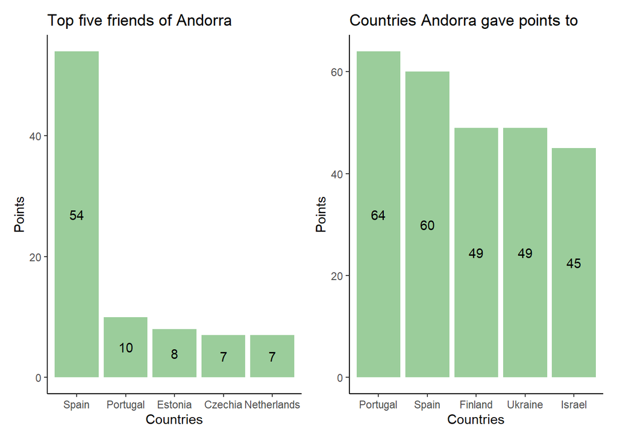